# S2 Download Comparison

Darius Görgen

4/5/2021

# Setup

This R Markdown is meant to compare different ways to download S2 data for a given AOI. We will use different sources such as a Google Cloud Bucket and AWS and different methodologies to query the endpoints for a spatiotemporal extent. For reasons of comparison we will query the AOI found in the `mapme.vegetation` package located in Pakistan for all endpoints. The task is simple: Calculate a NDVI composite for January, 2020 with clouds removed.

```r
# loading necessary libraries
library(sf)
library(terra)
library(rstac)
library(DBI)
library(bigrquery)
library(gdalcubes) # current github version, see https://github.com/appelmar/gdalcubes_R
library(openeo) # from https://github.com/Open-EO/openeo-r-client
library(getSpatialData) # from https://github.com/16EAGLE/getSpatialData
library(mapme.vegetation) # from https://github.com/mapme-initiative/mapme.vegetation
```

Let’s prepare the AOI.

```r
aoi = st_read(system.file("extdata", "testregion.gpkg", package = "mapme.vegetation"))
aoi = st_zm(aoi, drop = TRUE) # drop z dimension
aoi = st_as_sfc(st_bbox(aoi))
mapview::mapview(aoi)
```

[interactive chart not shown]

Let’s create a directory structure for our downloads.

```r
paths = c("download", "download/mapme", "download/bigquery", "download/aws", "download/gsd", "download/openeo")
for(path in paths) dir.create(path, showWarnings = F)
```

# MAPME

It is important to download some external software dependencies before the current approach works. Check [here](https://cloud.google.com/storage/docs/gsutil_install) for installation instructions of gsutil.

```r
sudo apt install -y google-cloud-sdk gsutil
```

Further, a project used for billing needs to be initiated with a Google account. The following command should lead through this process.

```r
gcloud init
```

Once this is done, we can use the existing MAPME code base to query the Google bucket. When running this command for the first time, the tile index is downloaded and transformed to a SQL data base for spatiotemporal queries. This consumes about 5 GB of space on the local disk but makes querying later on way faster. Later we will see how to use BigQuery so we do not have to download the tile index. We need to reset the timeout options because the zipped file is about 2 GB and starting from R 4.0 the timeout is set to 60 seconds which can cause troubles depending on the internet connection.

```r
options(timeout = max(300, getOption("timeout")))
downloadS2(aoi = aoi,
           time_window = c("2020-01-01", "2020-01-31"),
           time_period = "full",
           rootdir = "download/mapme/",
           extent_name = "test",
           use_db = TRUE,
           force_update = F,
           query_only = F)
```

```r
files = list.files("download/mapme", pattern = ".jp2|.tif", recursive = T, full.names = TRUE)
rasterfiles = calcIndex(files,
                        aoi = aoi,
                        epsg = "EPSG:32643",
                        dx = 20,
                        dy = 20,
                        dt = "P1M",
                        aggregation = "mean",
                        resampling = "bilinear",
                        tmpagg = FALSE,
                        timeframe = "complete",
                        index = "NDVI",
                        label = "mapme",
                        outdir = "download/mapme",
                        threads = 2)
```

```
## Size of the cube in x direction does not align with dx, extent will be enlarged by 4.216671 at both sides.
## Size of the cube in y direction does not align with dy, extent will be enlarged by 2.951257 at both sides.
```

# BigQuery

In this example we basically download the same data except that we use BigQuery to let the server process our spatitemporal query. For this to work the same prerequistes hold as for the MAPME approach namely a valid Google Account, a project that can be used for billing and that gsutil is installed. We will use the `bigrquery` package together with the `DBI` backend to send a SQL query to the server.

```r
billing = "sen2download"

con <- dbConnect(
  bigrquery::bigquery(),
  project = "bigquery-public-data",
  dataset = "cloud_storage_geo_index",
  billing = billing
)

bbox = st_bbox(aoi)
s_lat = as.numeric(bbox[2])
n_lat = as.numeric(bbox[4])
w_lon = as.numeric(bbox[1])
e_lon = as.numeric(bbox[3])
after = "2020-01-01"
before = "2020-01-31"

sql = paste0("SELECT * FROM `bigquery-public-data.cloud_storage_geo_index.sentinel_2_index`",
             " WHERE north_lat >= ", s_lat,
             " AND south_lat <= ", n_lat,
             " AND west_lon <= ", e_lon,
             " AND east_lon >= ", w_lon,
             " AND DATE(sensing_time) >= '", after,"'",
             "AND DATE(sensing_time) <= '", before, "'")
(results = dbGetQuery(con, sql))
```

```
Complete
Billed: 0 B
Downloading 34 rows in 1 pages.
```

```
Parsing [===========================================================================================================] ETA:  0s
```

| granule_id | product_id | datatake_identifier | mgrs_tile | sensing_time | geometric_quality_flag | generation_time | north_lat | south_lat | west_lon | east_lon | base_url | total_size | cloud_cover |
| --- | --- | --- | --- | --- | --- | --- | --- | --- | --- | --- | --- | --- | --- |
| L1C_T43SBU_A023640_20200101T055817 | S2A_MSIL1C_20200101T055231_N0208_R048_T43SBU_20200101T073908 | GS2A_20200101T055231_023640_N02.08 | 43SBU | 2020-01-01 05:59:25 | NA | 2020-01-01 07:39:08 | 35.22511 | 34.21221 | 71.83636 | 72.93452 | gs://gcp-public-data-sentinel-2/tiles/43/S/BU/S2A_MSIL1C_20200101T055231_N0208_R048_T43SBU_20200101T073908.SAFE | 514256272 | 99.7083 |
| L1C_T43SCU_A023640_20200101T055817 | S2A_MSIL1C_20200101T055231_N0208_R048_T43SCU_20200101T073908 | GS2A_20200101T055231_023640_N02.08 | 43SCU | 2020-01-01 05:59:22 | NA | 2020-01-01 07:39:08 | 35.23911 | 34.23378 | 72.80235 | 74.02030 | gs://gcp-public-data-sentinel-2/tiles/43/S/CU/S2A_MSIL1C_20200101T055231_N0208_R048_T43SCU_20200101T073908.SAFE | 651501914 | 99.9155 |
| L1C_T43SCT_A023640_20200101T055817 | S2A_MSIL1C_20200101T055231_N0208_R048_T43SCT_20200101T073908 | GS2A_20200101T055231_023640_N02.08 | 43SCT | 2020-01-01 05:59:36 | NA | 2020-01-01 07:39:08 | 34.33782 | 33.33286 | 72.82611 | 74.03052 | gs://gcp-public-data-sentinel-2/tiles/43/S/CT/S2A_MSIL1C_20200101T055231_N0208_R048_T43SCT_20200101T073908.SAFE | 751122877 | 99.3461 |
| L1C_T43SBT_A023640_20200101T055817 | S2A_MSIL1C_20200101T055231_N0208_R048_T43SBT_20200101T073908 | GS2A_20200101T055231_023640_N02.08 | 43SBT | 2020-01-01 05:59:40 | NA | 2020-01-01 07:39:08 | 34.32429 | 33.30964 | 71.75510 | 72.95604 | gs://gcp-public-data-sentinel-2/tiles/43/S/BT/S2A_MSIL1C_20200101T055231_N0208_R048_T43SBT_20200101T073908.SAFE | 673154613 | 99.6965 |
| L1C_T43SBU_A023826_20200114T060207 | S2A_MSIL1C_20200114T060211_N0208_R091_T43SBU_20200114T073212 | GS2A_20200114T060211_023826_N02.08 | 43SBU | 2020-01-14 06:09:21 | NA | 2020-01-14 07:32:12 | 35.22511 | 34.20976 | 71.70471 | 72.91105 | gs://gcp-public-data-sentinel-2/tiles/43/S/BU/S2A_MSIL1C_20200114T060211_N0208_R091_T43SBU_20200114T073212.SAFE | 816319014 | 6.3938 |
| L1C_T43SBU_A023926_20200121T055556 | S2A_MSIL1C_20200121T055141_N0208_R048_T43SBU_20200121T074330 | GS2A_20200121T055141_023926_N02.08 | 43SBU | 2020-01-21 05:59:24 | NA | 2020-01-21 07:43:30 | 35.22512 | 34.21224 | 71.83757 | 72.93452 | gs://gcp-public-data-sentinel-2/tiles/43/S/BU/S2A_MSIL1C_20200121T055141_N0208_R048_T43SBU_20200121T074330.SAFE | 509621548 | 99.9955 |
| L1C_T43SCT_A023926_20200121T055556 | S2A_MSIL1C_20200121T055141_N0208_R048_T43SCT_20200121T074330 | GS2A_20200121T055141_023926_N02.08 | 43SCT | 2020-01-21 05:59:35 | NA | 2020-01-21 07:43:30 | 34.33782 | 33.33286 | 72.82611 | 74.03052 | gs://gcp-public-data-sentinel-2/tiles/43/S/CT/S2A_MSIL1C_20200121T055141_N0208_R048_T43SCT_20200121T074330.SAFE | 619359914 | 99.9871 |
| L1C_T43SBU_A024069_20200131T055403 | S2A_MSIL1C_20200131T055051_N0208_R048_T43SBU_20200131T074554 | GS2A_20200131T055051_024069_N02.08 | 43SBU | 2020-01-31 05:59:23 | NA | 2020-01-31 07:45:54 | 35.22511 | 34.21219 | 71.83572 | 72.93451 | gs://gcp-public-data-sentinel-2/tiles/43/S/BU/S2A_MSIL1C_20200131T055051_N0208_R048_T43SBU_20200131T074554.SAFE | 594875011 | 94.7363 |
| L1C_T43SCT_A024069_20200131T055403 | S2A_MSIL1C_20200131T055051_N0208_R048_T43SCT_20200131T074554 | GS2A_20200131T055051_024069_N02.08 | 43SCT | 2020-01-31 05:59:34 | NA | 2020-01-31 07:45:54 | 34.33782 | 33.33286 | 72.82611 | 74.03052 | gs://gcp-public-data-sentinel-2/tiles/43/S/CT/S2A_MSIL1C_20200131T055051_N0208_R048_T43SCT_20200131T074554.SAFE | 816148838 | 69.2470 |
| L1C_T43SCU_A024069_20200131T055403 | S2A_MSIL1C_20200131T055051_N0208_R048_T43SCU_20200131T074554 | GS2A_20200131T055051_024069_N02.08 | 43SCU | 2020-01-31 05:59:19 | NA | 2020-01-31 07:45:54 | 35.23911 | 34.23378 | 72.80235 | 74.02030 | gs://gcp-public-data-sentinel-2/tiles/43/S/CU/S2A_MSIL1C_20200131T055051_N0208_R048_T43SCU_20200131T074554.SAFE | 802990008 | 90.2761 |

[output cut: 24 more lines]

We will use a similar code that is used within the MAPME package which will automatically create download the data via `gsutil` and create a cloudmask GTiff.

```r
create_cloudmask = TRUE
outdir = "download/bigquery/"
names = basename(results$base_url)
for(i in 1:nrow(results)){
  if(file.exists(file.path(outdir, names[i]))){
    next
  } else {

    # prepare command with gsutil
    command = paste0("gsutil -m cp -r ", results$base_url[i], " ", outdir)
    dir.create(outdir, showWarnings = F, recursive = T)
    # try to download and save output in s
    s = try(suppressWarnings(system(command, intern = T, ignore.stderr = T)))

    # some files are not present in GoogleCloud Bucket, thus the download fails
    # this is only the case for very few files
    if(!is.null(attributes(s)$status)){
      message(paste0("\n File ", names[i], " could not be downloaded."))

    } else {
      # creating some empty folders which are needed by sen2r/sen2cor
      # functionality to allow further processing
      dir.create(file.path(outdir, names[i], "AUX_DATA"), showWarnings = F)
      dir.create(file.path(outdir, names[i], "HTML"), showWarnings = F)
      message(paste0("\n File ", names[i], " succesfully downloaded."))
      if(create_cloudmask) createCloudMask(file.path(outdir, names[i]), overwrite = F)
    }
  }
}
```

We then can use the same functionality already implemented in the MAPME package to caluclate the NDVI.

```r
files = list.files("download/bigquery", pattern = ".jp2|.tif", recursive = T, full.names = TRUE)
rasterfiles = calcIndex(files,
                        aoi = aoi,
                        epsg = "EPSG:32643",
                        dx = 20,
                        dy = 20,
                        dt = "P1M",
                        aggregation = "mean",
                        resampling = "bilinear",
                        tmpagg = FALSE,
                        timeframe = "complete",
                        index = "NDVI",
                        label = "bigquery",
                        outdir = "download/bigquery",
                        threads = 2)
```

```
## Size of the cube in x direction does not align with dx, extent will be enlarged by 4.216671 at both sides.
## Size of the cube in y direction does not align with dy, extent will be enlarged by 2.951257 at both sides.
```

# AWS

We can download surface reflectance values from AWS. These are available in the SAFE format as well as cloud optimized GTiffs. No authentication is necessary. The `rstac` package can be used to easily query a spatiotemporal extent of interest because AWS has implemented the STAC API. We can specifically select the bands we want to download. Because right now, we are interested in the NDVI we will only download the required bands. However, when more than one index shall be calculated it is advisable to download all bands.

```r
s = stac("https://earth-search.aws.element84.com/v0")
q <- s %>% stac_search(collections = "sentinel-s2-l2a-cogs",
                       bbox = as.numeric(bbox), # Geneva
                       datetime = "2020-01-01/2020-01-31",
                       limit = 500)
q %>% post_request() -> items
assets = c("B04","B08","SCL")
assets_download(items, output_dir = "download/aws/", assets_name = assets)
```

```
###STACItemCollection
- matched feature(s): 28
- features (28 item(s)):
  - S2A_43SBT_20200131_0_L2A
  - S2A_43SCT_20200131_0_L2A
  - S2A_43SBU_20200131_0_L2A
  - S2A_43SCU_20200131_0_L2A
  - S2B_43SBT_20200126_0_L2A
  - S2B_43SCT_20200126_0_L2A
  - S2B_43SBU_20200126_0_L2A
  - S2B_43SCU_20200126_0_L2A
  - S2A_43SBT_20200121_0_L2A
  - S2A_43SCT_20200121_0_L2A
  - ... with 18 more feature(s).
- field(s): type, stac_version, stac_extensions, context, numberMatched, numberReturned, features, links
```

We than can proceed to calculate the NDVI composite using the `gdalcubes` package. We needed to write a custom format definition because the package currently does not know how to interpret the COG version of the sentinel data.

```r
files = list.files("download/aws/", full.names = T)
files = files[-grep("NDVI", files)]
col = gdalcubes::create_image_collection(files, format = "s2_cog.json")

aoi_proj = st_transform(aoi, 32643)
bbox = st_bbox(aoi_proj)
v = cube_view(srs = "EPSG:32643",
              dx = 20,
              dy = 20,
              dt = "P1M",
              aggregation = "mean",
              resampling = "bilinear",
              extent = list(t0 = "2020-01-01",
                            t1 = "2020-01-31",
                            left = bbox[1],
                            right = bbox[3],
                            top = bbox[4],
                            bottom = bbox[2]))
```

```
## Size of the cube in x direction does not align with dx, extent will be enlarged by 4.216671 at both sides.
## Size of the cube in y direction does not align with dy, extent will be enlarged by 2.951257 at both sides.
```

```r
S2.mask = image_mask("SCL", values=c(3,8,9)) # clouds and cloud shadows
gdalcubes_options(threads = 4)
raster_cube(col, v, mask = S2.mask) %>%
  select_bands(c("B04","B08","SCL")) %>%
  apply_pixel("(B08-B04)/(B08+B04)", "NDVI") %>%
  write_tif(dir = "download/aws/", prefix = "aws-NDVI-")
```

# getSpatialData

We can use the package `getSpatialData` to retrieve data from Copernicus Hub. L1C data can directly downloaded while the Hub currently does not provide access to all L2A data. Also the package currently shows a bug within the the function to check the availability of L2A data which we can hack by adding a column called `download_available` to the results object and start downloading directly.

```r
set_archive("download/gsd")
set_aoi(aoi)
```

```
although coordinates are longitude/latitude, st_union assumes that they are planar
```

```r
login_CopHub(username = "goergen")
```

```
Login successfull. ESA Copernicus credentials have been saved for the current session.
```

```r
records <- get_records(time_range = c("2020-01-01", "2020-01-31"),
                       products = c("Sentinel-2"))
```

```
Searching records for product name 'Sentinel-2'...
```

```
although coordinates are longitude/latitude, st_union assumes that they are planar
although coordinates are longitude/latitude, st_union assumes that they are planar
```

```r
records2A <- records[records$level == "Level-2A" | records$level == "sr",]
records2A$download_available<-T
results = get_data(records2A, dir_out = "download/gsd/")
```

[output not shown]

[output cut: 9 more lines]

The data is downloaded into zip directories. `gdalcubes` is able to initiate an image collection without the need to unzip the files.

```r
files = list.files("download/gsd/Sentinel-2/", full.names = T)
col = create_image_collection(files, format = "Sentinel2_L2A")
```

```r
S2.mask = image_mask("SCL", values=c(3,8,9)) # clouds and cloud shadows
gdalcubes_options(threads = 4)
raster_cube(col, v, mask = S2.mask) %>%
  select_bands(c("B04","B08","SCL")) %>%
  apply_pixel("(B08-B04)/(B08+B04)", "NDVI") %>%
  write_tif(dir = "download/gsd/", prefix = "gsd-NDVI-")
```

# openEO

Using the GEE backend with openEO currently there is no straight-forward way for cloud removal based on the SCL layer because the backend has not implemented the necessary processes. We will therefor omit cloud removal.

```r
jobs = list_jobs()
jobs[names(jobs) == job_id$id]
```

```
$eRSppVfyWlfON5mq
Job ID:     eRSppVfyWlfON5mq
Title:      PAK NDVI Temp
Description:    ---
Status:     finished
Created:    2021-04-07T12:09:18Z
Updated:    2021-04-07T12:09:18Z
Plan:       free
Costs:      0
Budget:     ---
```

```r
file = download_results(job = job_id, folder = "./download/openeo")
file = file[[1]]
unzip(file, exdir = "download/openeo/")
file = list.files("download/openeo", pattern = ".tif", full.names = T)
target = rast("download/aws/aws-NDVI-2020-01.tif")
source = rast(file)
out = project(source, target)
writeRaster(out, "download/openeo/openeo-NDVI.tif", overwrite = T)
```

# Considerations

Let’s compare the results!

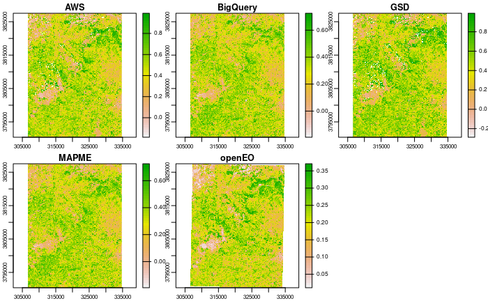

```r
ndvi_files = list.files("download/", pattern = "NDVI", recursive = T, full.names = T)
ndvis = rast(ndvi_files)
names(ndvis) = c("AWS", "BigQuery", "GSD", "MAPME", "openEO")
plot(ndvis)
```

## Google Bucket

- available data sets:
  - S2 L1C
  - (S2 L2A - but complex query)
  - Landsat Archive Level 1
- Pros:
  - S2 on European Servers -> faster download
- Cons:
  - Landsat on US servers -> slower download
  - needs a lot of software and authentication
  - complex spatiotemporal queries (local csv or bigquery)
  - BOA not available
  - unclear licensing: GEE needs commercial license - what about the bucket
  - using BigQuery means we will only be able to download from Google with the code

## AWS

- available data sets:
  - S2 L1C
  - S2 L2A
  - S2 L2A COG
  - L8 L1
- Pros:
  - no user authentication
  - easy spatiotemporal queries via STAC
  - using STAC means that we can use the code with any STAC endpoint and just have to change the URL
  - availability of BOA for S2
  - potentially no need to download with gdalcubes and server in US using COGs
  - data can readily used commercially
- Cons:
  - server in US -> slower downloads

## SentinelHub

- available data sets:
  - S1 GRD
  - S2 L1C & L2A
  - S3 L1B
  - S5P
  - DEM Mapzen & Copernicus
  - MODIS BRDF
  - L8 L1 & L2
- Pros:
  - servers in EU
  - more data available compared to Google & AWS
  - data can readily be used commercially
- Cons:
  - at least 30 euros per month depending on quota
  - should work as a STAC catalog but currently only supports special syntax
  - so we also will need to develop code that we can only use with sentinel hub

## OpenEO

- available data sets:
  - depends on provider, with GEE many data sets
- Pros:
  - no need for download because data is processed on backend
  - no real vendor lock-in for developed code
  - can be used commercially based on selected membership
- Cons:
  - membership with processing quouta needs to be purchased
  - quoutas are just in the process of determination
  - not all functionality is always available

## GetSpatialData

- R package with support for:
  - CopernicusHub
  - USGS
  - NASA Earth Data
- data sets:
  - 159 total among them:
  - S1
  - S2
  - Landsat
  - MODIS products (almost any)
  - SRTM
- Pros:
  - already implemented API to get many different data sets
- Cons:
  - seems not to be maintained since November 2020, a lot of issues raised, pretty buggy
  - package can only be used to download data, no cloud processing
  - needs authentication based on which data to download
  - unavailable BOA products need to be ordered